# Accuracy by Difficulty Levels

Christian Medeiros Adriano

June 2, 2017

## Analysis of answer accuracy by the difficulty level of questions

Are workers more accurate in their answers when they consider questions less difficult?

## How do the accuracy of answers options (YES,NO) relate with the difficulty level of the questions?

```
## [1] "All Answers - difficulty"
##   Difficulty  Accuracy Precision    Recall Answers
## 1          1 0.8446115 0.4487179 0.6481481     399
## 2          2 0.7840671 0.4117647 0.4941176     477
## 3          3 0.6784203 0.3073394 0.4652778     709
## 4          4 0.6439232 0.3072289 0.4951456     469
## 5          5 0.5954545 0.3222222 0.5087719     220
```

```
## Total answers:2274
```

```
## [1] "Only YES Answers - difficulty"
##   Difficulty  Accuracy Precision Recall Answers
## 1          1 0.4487179 0.4487179      1      78
## 2          2 0.4117647 0.4117647      1     102
## 3          3 0.3073394 0.3073394      1     218
## 4          4 0.3072289 0.3072289      1     166
## 5          5 0.3222222 0.3222222      1      90
```

```
## Total answers:654
```

```
## [1] "Only NO Answers - difficulty"
##   Difficulty  Accuracy Precision Recall Answers
## 1          1 0.9408100         0      0     321
## 2          2 0.8853333         0      0     375
## 3          3 0.8431772         0      0     491
## 4          4 0.8283828         0      0     303
## 5          5 0.7846154         0      0     130
```

```
## Total answers:1620
```

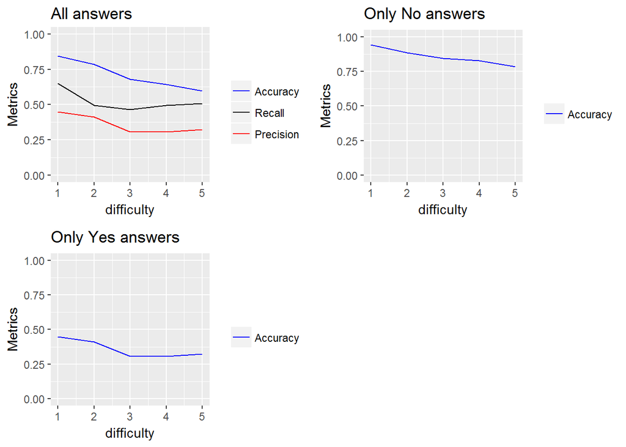

## How do the accuracy of answers by worker profession relate with the difficulty level of the questions?

```
## [1] "Only PROFESSIONAL_DEVELOPERS - difficulty"
##   Difficulty  Accuracy Precision    Recall Answers
## 1          1 0.8333333 0.4473684 0.7391304     162
## 2          2 0.7783784 0.4000000 0.4848485     185
## 3          3 0.6889632 0.3068182 0.4576271     299
## 4          4 0.6406250 0.2647059 0.4864865     192
## 5          5 0.6551724 0.5000000 0.5666667      87
```

```
## Total answers:925
```

```
## [1] "Only HOBBYIST - difficulty"
##   Difficulty  Accuracy Precision    Recall Answers
## 1          1 0.8552632 0.2727273 0.5000000      76
## 2          2 0.8108108 0.5200000 0.5909091     111
## 3          3 0.6827586 0.3958333 0.5277778     145
## 4          4 0.6571429 0.3421053 0.5416667     105
## 5          5 0.6440678 0.3200000 0.6666667      59
```

```
## Total answers:496
```

```
## [1] "Only GRADUATE_STUDENT - difficulty"
##   Difficulty  Accuracy Precision    Recall Answers
## 1          1 0.9000000 0.6000000 0.7500000      30
## 2          2 0.8529412 0.5714286 0.6666667      34
## 3          3 0.5609756 0.1764706 0.4285714      82
## 4          4 0.7142857 0.3684211 0.5384615      63
## 5          5 0.5666667 0.2307692 0.5000000      30
```

```
## Total answers:239
```

[output not shown]

[output not shown]

```
## [1] "Only OTHER - difficulty"
##   Difficulty  Accuracy Precision    Recall Answers
## 1          1 0.8571429 0.6000000 0.7500000      42
## 2          2 0.7631579 0.5000000 0.5555556      38
## 3          3 0.7500000 0.2000000 0.4000000      44
## 4          4 0.7407407 0.5833333 0.7777778      27
## 5          5 0.5000000 0.0000000       NaN      10
```

```
## Total answers:161
```

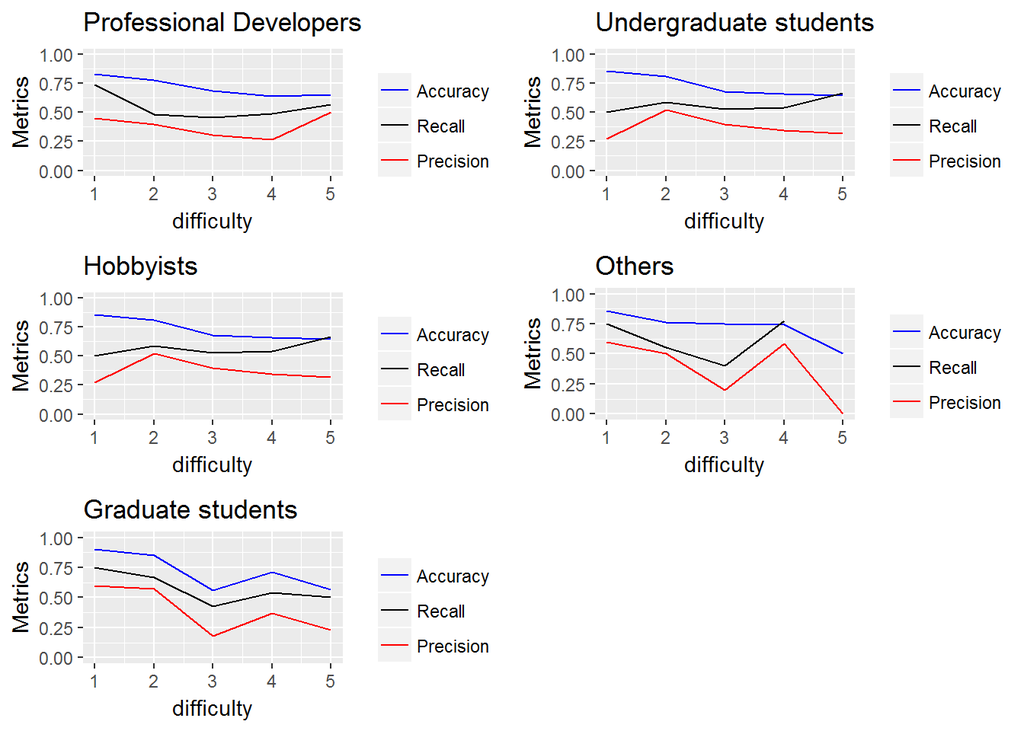

As the charts above show, even across professions accuracy and difficulty follows are inversely proportionate.

## Is accuracy of answers also inverly related to question difficulty across different Java methods?

```
## [1] "Only HIT01_8 - difficulty"
##   Difficulty  Accuracy Precision    Recall Answers
## 1          1 0.9677419 1.0000000 0.8666667      62
## 2          2 0.8627451 0.5000000 0.5714286      51
## 3          3 0.7073171 0.3888889 0.8750000      41
## 4          4 0.6086957 0.2857143 0.3333333      23
## 5          5 0.6875000 0.2500000 0.3333333      16
```

```
## Total answers:193
```

```
## [1] "Only HIT02_24 - difficulty"
##   Difficulty  Accuracy Precision    Recall Answers
## 1          1 0.6842105 0.2000000 0.3333333      19
## 2          2 0.6296296 0.5555556 0.4545455      27
## 3          3 0.5675676 0.5294118 0.5294118      37
## 4          4 0.5238095 0.1666667 1.0000000      21
## 5          5 0.5714286 0.3333333 0.5000000       7
```

```
## Total answers:111
```

```
## [1] "Only HIT03_6 - difficulty"
##   Difficulty  Accuracy Precision    Recall Answers
## 1          1 0.8387097 0.3333333 0.2500000      31
## 2          2 0.6862745 0.2142857 0.3750000      51
## 3          3 0.6436782 0.2400000 0.3333333      87
## 4          4 0.6500000 0.4666667 0.5384615      80
## 5          5 0.6111111 0.4117647 0.6363636      36
```

```
## Total answers:285
```

```
## [1] "Only HIT04_7 - difficulty"
##   Difficulty  Accuracy Precision    Recall Answers
## 1          1 0.8085106 0.2000000 0.6666667      47
## 2          2 0.8547009 0.2941176 0.5000000     117
## 3          3 0.7028302 0.2459016 0.4687500     212
## 4          4 0.7225806 0.2857143 0.6363636     155
## 5          5 0.5625000 0.2105263 0.6153846      80
```

```
## Total answers:611
```

```
## [1] "Only HIT05_35 - difficulty"
##   Difficulty  Accuracy Precision    Recall Answers
## 1          1 0.5882353 0.3333333 0.7500000      17
## 2          2 0.7142857 0.6363636 0.7777778      21
## 3          3 0.6129032 0.4545455 0.4545455      62
## 4          4 0.5116279 0.3846154 0.6666667      43
## 5          5 0.5625000 0.4285714 0.5000000      16
```

```
## Total answers:159
```

```
## [1] "Only HIT06_51 - difficulty"
##   Difficulty  Accuracy Precision    Recall Answers
## 1          1 0.8571429 0.5000000 0.4000000      35
## 2          2 0.7916667 0.3333333 0.2500000      48
## 3          3 0.7043478 0.1851852 0.2941176     115
## 4          4 0.6582278 0.1818182 0.3076923      79
## 5          5 0.6562500 0.3636364 0.5000000      32
```

```
## Total answers:309
```

```
## [1] "Only HIT07_33 - difficulty"
##   Difficulty  Accuracy Precision    Recall Answers
## 1          1 0.9600000 1.0000000 0.8571429      25
## 2          2 0.8055556 0.7777778 0.5833333      36
## 3          3 0.6382979 0.6153846 0.4000000      47
## 4          4 0.4242424 0.2500000 0.2307692      33
## 5          5 0.3333333 0.5000000 0.2500000       6
```

```
## Total answers:147
```

```
## [1] "Only HIT08_54 - difficulty"
##   Difficulty  Accuracy Precision    Recall Answers
## 1          1 0.8343558 0.2500000 0.5384615     163
## 2          2 0.7619048 0.3214286 0.4500000     126
## 3          3 0.7129630 0.2000000 0.7000000     108
## 4          4 0.7142857 0.2500000 0.3333333      35
## 5          5 0.6296296 0.5000000 0.4000000      27
```

```
## Total answers:459
```

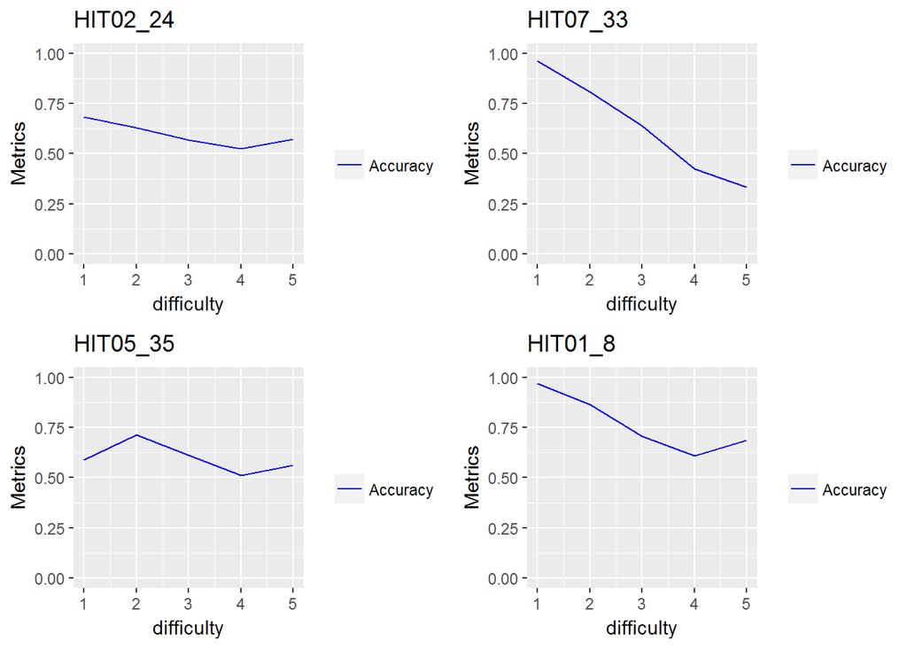

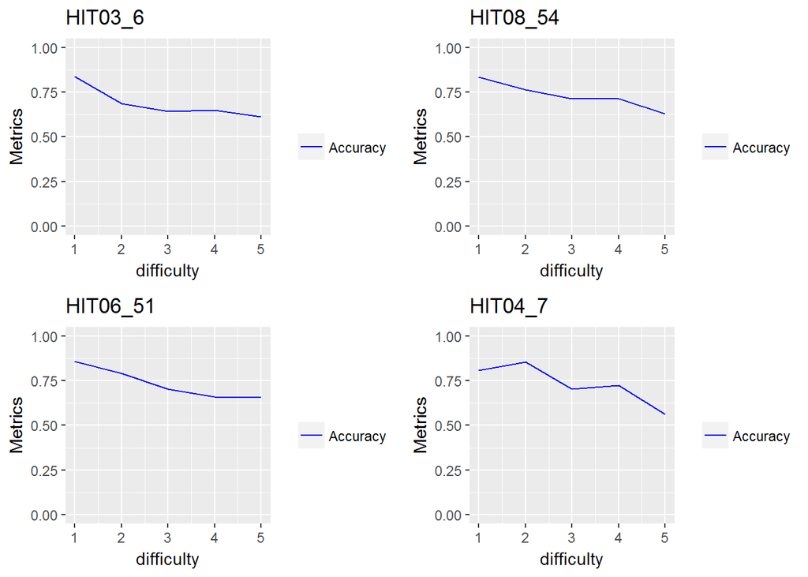

## Considering only professional programmers, is accuracy of answers also inversely related to question difficulty across different Java methods ?

```
## [1] "Only HIT01_8 - difficulty"
##   Difficulty  Accuracy Precision    Recall Answers
## 1          1 0.9565217 1.0000000 0.8333333      23
## 2          2 0.8421053 0.3333333 0.5000000      19
## 3          3 0.8000000 0.4000000 1.0000000      15
## 4          4 0.3333333 0.2000000 0.3333333       9
## 5          5 0.8571429 1.0000000 0.5000000       7
```

```
## Total answers:73
```

```
## [1] "Only HIT02_24 - difficulty"
##   Difficulty  Accuracy Precision    Recall Answers
## 1          1 0.8000000 0.0000000 0.0000000       5
## 2          2 0.7500000 0.7500000 0.6000000      12
## 3          3 0.6666667 0.5454545 0.8571429      18
## 4          4 0.6666667 0.3333333 1.0000000      12
## 5          5 0.8000000 1.0000000 0.5000000       5
```

```
## Total answers:52
```

```
## [1] "Only HIT03_6 - difficulty"
##   Difficulty  Accuracy Precision    Recall Answers
## 1          1 0.8461538 0.5000000 0.5000000      13
## 2          2 0.6190476 0.2857143 0.4000000      21
## 3          3 0.6428571 0.2142857 0.4285714      42
## 4          4 0.5833333 0.2727273 0.3000000      36
## 5          5 0.5909091 0.4000000 0.5714286      22
```

```
## Total answers:134
```

```
## [1] "Only HIT04_7 - difficulty"
##   Difficulty  Accuracy Precision    Recall Answers
## 1          1 0.7333333 0.2000000 1.0000000      15
## 2          2 0.9000000 0.3333333 0.6666667      50
## 3          3 0.7674419 0.3684211 0.4666667      86
## 4          4 0.7352941 0.2272727 0.8333333      68
## 5          5 0.6315789 0.5000000 0.7142857      19
```

```
## Total answers:238
```

```
## [1] "Only HIT05_35 - difficulty"
##   Difficulty  Accuracy Precision    Recall Answers
## 1          1 0.6250000 0.4000000 1.0000000       8
## 2          2 0.5714286 0.5000000 1.0000000       7
## 3          3 0.5555556 0.2857143 0.2222222      27
## 4          4 0.4761905 0.3571429 0.7142857      21
## 5          5 0.6363636 0.5000000 0.5000000      11
```

```
## Total answers:74
```

```
## [1] "Only HIT06_51 - difficulty"
##   Difficulty  Accuracy Precision    Recall Answers
## 1          1 0.8235294 0.3333333 0.5000000      17
## 2          2 0.6666667 0.2500000 0.3333333      15
## 3          3 0.6538462 0.1428571 0.2500000      52
## 4          4 0.7037037 0.2000000 0.2000000      27
## 5          5 0.6470588 0.3333333 0.5000000      17
```

```
## Total answers:128
```

```
## [1] "Only HIT07_33 - difficulty"
##   Difficulty  Accuracy Precision    Recall Answers
## 1          1 1.0000000 1.0000000 1.0000000      11
## 2          2 0.8333333 0.6666667 0.5000000      18
## 3          3 0.6000000 0.5000000 0.3750000      20
## 4          4 0.6666667 0.5000000 0.3333333       9
## 5          5       NaN 0.0000000       NaN       0
```

```
## Total answers:58
```

```
## [1] "Only HIT08_54 - difficulty"
##   Difficulty  Accuracy Precision    Recall Answers
## 1          1 0.8142857 0.2666667 0.6666667      70
## 2          2 0.7441860 0.2857143 0.2500000      43
## 3          3 0.7179487 0.1666667 0.6666667      39
## 4          4 0.6000000 0.0000000 0.0000000      10
## 5          5 0.6666667 1.0000000 0.5000000       6
```

```
## Total answers:168
```

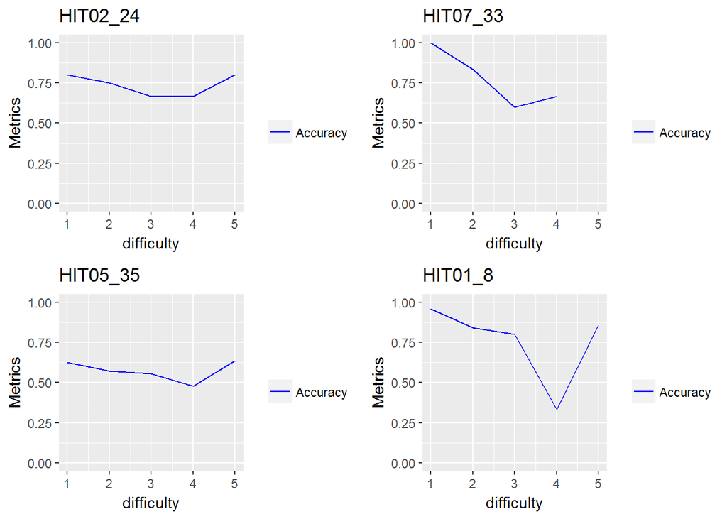

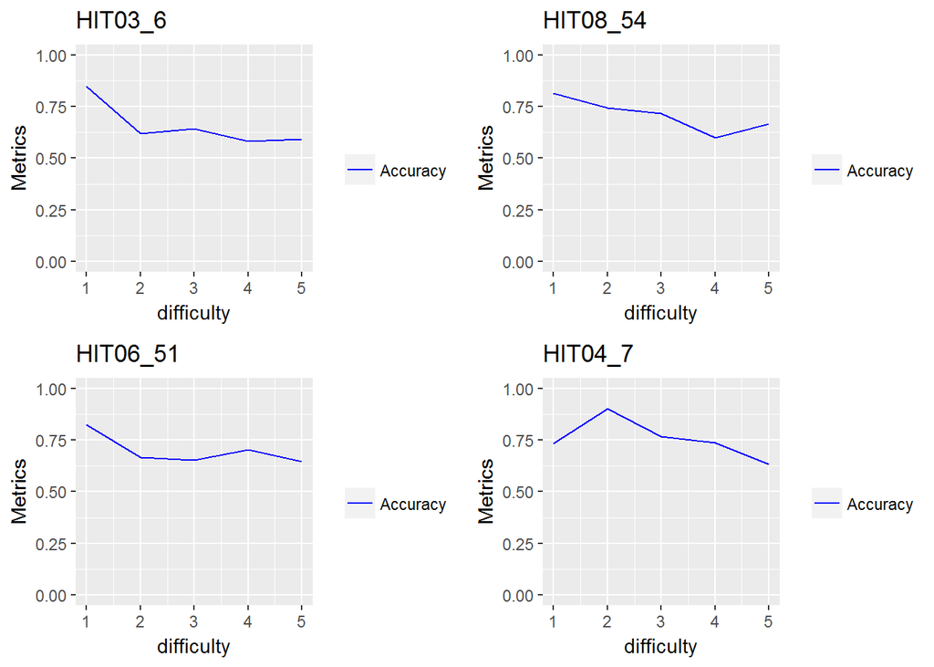

## Considering only **undergraduate students**, is accuracy of answers also inversely related to question difficulty across different Java methods ?

Yes, for 7 out of 8 Java Methods as the charts below show

```
## [1] "Only HIT01_8 - difficulty"
##   Difficulty  Accuracy Precision    Recall Answers
## 1          1 0.9411765       1.0 0.8000000      17
## 2          2 0.9285714       1.0 0.5000000      14
## 3          3 0.7500000       0.4 0.6666667      16
## 4          4 0.5000000       0.0 0.0000000       2
## 5          5 0.5000000       0.0       NaN       4
```

```
## Total answers:53
```

```
## [1] "Only HIT02_24 - difficulty"
##   Difficulty  Accuracy Precision Recall Answers
## 1          1 0.6000000       0.0    NaN       5
## 2          2 0.4000000       0.0    0.0       5
## 3          3 0.4285714       0.5    0.5       7
## 4          4 0.5000000       0.0    NaN       2
## 5          5 0.0000000       0.0    NaN       1
```

```
## Total answers:20
```

```
## [1] "Only HIT03_6 - difficulty"
##   Difficulty  Accuracy Precision    Recall Answers
## 1          1 1.0000000 0.0000000       NaN       5
## 2          2 0.7272727 0.0000000       NaN      11
## 3          3 0.7058824 0.6666667 0.3333333      17
## 4          4 0.4615385 0.4000000 0.3333333      13
## 5          5 0.0000000 0.0000000 0.0000000       2
```

```
## Total answers:48
```

```
## [1] "Only HIT04_7 - difficulty"
##   Difficulty  Accuracy Precision    Recall Answers
## 1          1 0.8666667 0.0000000 0.0000000      15
## 2          2 0.6956522 0.1666667 0.3333333      23
## 3          3 0.6410256 0.1875000 0.7500000      39
## 4          4 0.6250000 0.2000000 0.3333333      32
## 5          5 0.4444444 0.1250000 0.2500000      18
```

```
## Total answers:127
```

```
## [1] "Only HIT05_35 - difficulty"
##   Difficulty  Accuracy Precision    Recall Answers
## 1          1 0.8000000 0.0000000 0.0000000       5
## 2          2 0.7500000 0.0000000 0.0000000       4
## 3          3 0.5454545 0.4000000 0.5000000      11
## 4          4 0.3333333 0.3333333 0.3333333       6
## 5          5 0.3333333 0.0000000 0.0000000       3
```

```
## Total answers:29
```

```
## [1] "Only HIT06_51 - difficulty"
##   Difficulty  Accuracy Precision Recall Answers
## 1          1 0.8888889       1.0    0.5       9
## 2          2 0.8571429       0.5    0.5      14
## 3          3 0.7333333       0.0    0.0      15
## 4          4 0.5238095       0.0    0.0      21
## 5          5 0.5000000       0.0    0.0       2
```

```
## Total answers:61
```

```
## [1] "Only HIT07_33 - difficulty"
##   Difficulty  Accuracy Precision    Recall Answers
## 1          1 0.7500000       1.0 0.5000000       4
## 2          2 0.8750000       0.0 0.0000000       8
## 3          3 0.6666667       1.0 0.3333333       6
## 4          4 0.5000000       0.5 0.5000000       4
## 5          5 0.0000000       0.0 0.0000000       1
```

```
## Total answers:23
```

```
## [1] "Only HIT08_54 - difficulty"
##   Difficulty  Accuracy Precision    Recall Answers
## 1          1 0.7586207 0.0000000 0.0000000      29
## 2          2 0.7000000 0.1428571 0.2500000      30
## 3          3 0.8571429 0.3333333 0.3333333      28
## 4          4 1.0000000 0.0000000       NaN       2
## 5          5 0.6666667 0.0000000 0.0000000       3
```

```
## Total answers:92
```

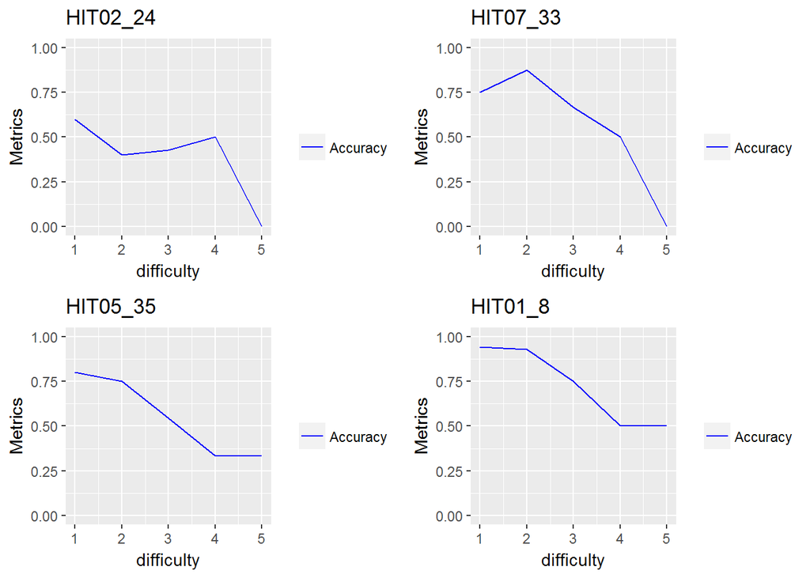

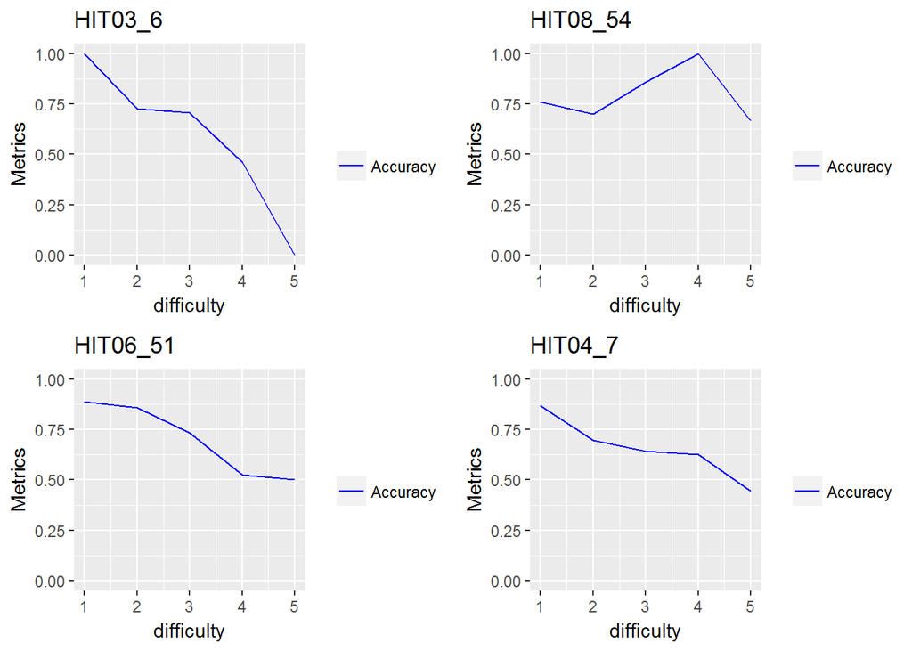